# 5 Non-linear Cox

## 1 Learning objectives

**Note**

By the end of this lecture, you should be able to:

- Understand the **linearity assumption** for continuous covariates in the Cox model
- Diagnose violations of linearity using **martingale residuals**
- Fit a **nonlinear Cox model** using **smooth functions**
- Interpret **nonlinear hazard ratios** relative to a reference value
- Recognise when **nonlinear Cox models** are preferable to standard Cox models

## 2 Linearity assumption in the Cox model

In the standard Cox proportional hazards model, continuous covariates are assumed to have a **linear effect on the log hazard**.

For a continuous covariate ( X ), the model assumes:

$$\log h(t \mid X) = \beta X$$

This implies that:

- A **1-unit increase** in $X$ leads to a **constant multiplicative change** in the hazard
- The hazard ratio associated with $X$ is the same **across its entire range**

**Warning**

The proportional hazards assumption concerns **how effects change over time**,  
whereas the linearity assumption concerns **how effects change across values of a covariate**.

## 3 Why the linearity assumption may be unrealistic

In many biomedical applications, the effect of a continuous variable on risk is **not linear**.

Examples include:

- Kidney function (eGFR)
- Blood pressure
- Biomarker concentrations
- Age

For example, a decrease in eGFR from 90 to 60 may have a very different impact on risk than a decrease from 60 to 30.

**Warning**

If the true relationship is nonlinear but we assume linearity,  
the Cox model can produce **biased effect estimates and misleading interpretations**.

## 4 Diagnosing nonlinearity using martingale residuals

One way to assess the linearity assumption is to examine **martingale residuals** from a Cox model.

The idea is to:

1. Fit a Cox model assuming linear effects
2. Plot martingale residuals against the continuous covariate
3. Look for systematic patterns
- A **random cloud** around zero suggests linearity
- A **curved or structured pattern** suggests nonlinearity

## 5 Martingale residuals

Martingale residuals are defined for **each individual** and are used to assess the **functional form** of covariates, particularly the **linearity assumption** for continuous predictors.

For subject $i$, the martingale residual is defined as:

$$M_i = \delta_i - \hat{H}_0(T_i)\exp(\hat{\beta}^\top X_i)$$

where:

- $\delta_i$ is the event indicator (1 = event, 0 = censored)
- $T_i$ is the observed event or censoring time
- $\hat{H}_0(T_i)$ is the estimated baseline cumulative hazard
- $X_i$ is the vector of covariates
- $\hat{\beta}$ are the estimated regression coefficients

Intuitively:

- $\delta_i$ is what we **observed**
- $\hat{H}_0(T_i)\exp(\hat{\beta}^\top X_i)$ is what the model **expected**

So the martingale residual measures the **difference between observed and expected number of events**.

**Note**

Martingale residuals take values in the range $(-\infty, 1]$ and tend to be highly skewed.

## 6 Schoenfeld residuals (for comparison)

Schoenfeld residuals are defined **only at event times** and are used to assess the **proportional hazards (PH) assumption**, not linearity.

For subject $i$ who experiences an event at time $t_i$, the Schoenfeld residual for covariate $X_k$ is:

$$r_{ik} = X_{ik} - \mathbb{E}(X_k \mid t_i)$$

where the expectation is taken over the **risk set at time** $t_i$.

Schoenfeld residuals represent the difference between:

- The observed covariate value at the event time
- The expected covariate value under the fitted Cox model

## 7 Martingale vs Schoenfeld residuals

The key differences are:

- **Martingale residuals**
  - Defined for **all individuals**
  - Used to assess **functional form and linearity**
  - Plotted against covariate values
- **Schoenfeld residuals**
  - Defined **only at event times**
  - Used to assess **proportional hazards**
  - Plotted against **time**

**Tip**

Use **Schoenfeld residuals** to check *whether effects change over time*,  
and **martingale residuals** to check *whether effects are linear in covariate space*.

## 8 Example: Evidence of nonlinearity in a Cox model

We illustrate the issue of nonlinearity using a continuous predictor (e.g. **eGFR**).

We begin by fitting a **standard Cox proportional hazards model** that assumes a **linear effect** of eGFR on the log hazard. Next, look at the Martingale residuals of this fitted model.

**Show R code**

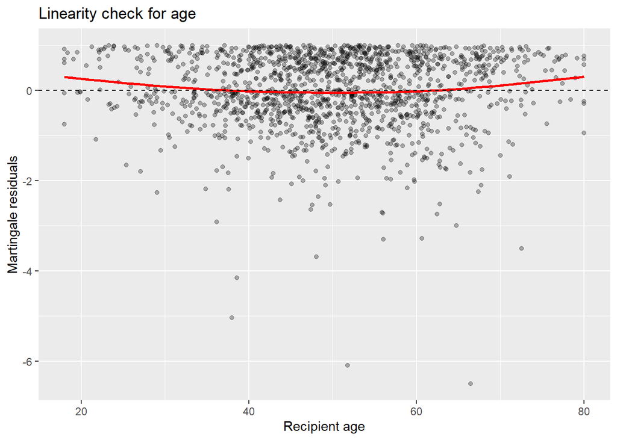

```r
library(survival)
library(ggplot2)

nonlinear_data <- read.csv("https://raw.githubusercontent.com/NicoleDeLaMata/AdvancedSurvival/refs/heads/Data/nonlinear_cox_data.csv")

cox_linear <- coxph(
  Surv(time, status) ~ donor_type +
                        recipient_sex
                      + age_rec + egfr0,
                        data = nonlinear_data
                        )

mart <- residuals(cox_linear, type = "martingale")

#age
ggplot(nonlinear_data, aes(age_rec, mart)) +
  geom_point(alpha = 0.3) +
  geom_smooth(se = FALSE, col = "red") +
  geom_hline(yintercept = 0, linetype = "dashed") +
  labs(
    x = "Recipient age",
    y = "Martingale residuals",
    title = "Linearity check for age"
  )
```

**Show R code**

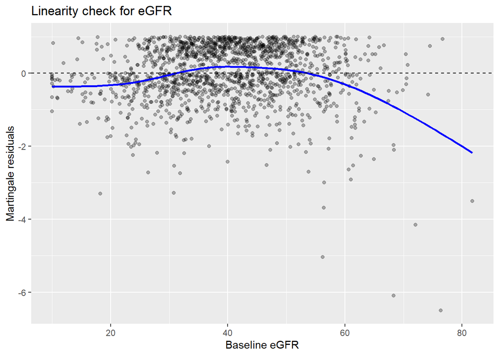

```r
#egfr

ggplot(nonlinear_data, aes(egfr0, mart)) +
  geom_point(alpha = 0.3) +
  geom_smooth(se = FALSE, col = "blue") +
  geom_hline(yintercept = 0, linetype = "dashed") +
  labs(
    x = "Baseline eGFR",
    y = "Martingale residuals",
    title = "Linearity check for eGFR"
  )
```

**Interpretation of the martingale residual plot**

In this plot:

- The points represent martingale residuals
- The red curve is a smoothed trend (loess/lowess) for age and the blue curve is smoothed trend for eGFR at baseline.

**Warning**

If the effect of eGFR at baseline and age were truly linear on the log hazard scale, we would expect the smooth curve to be approximately flat around zero.

Instead, we observe a systematic curved pattern, indicating that the effect of eGFR at baseline and age on graft failure risk is not linear.

This suggests that:

- The linearity assumption for eGFR at baseline and age is violated.
- A standard Cox model with a linear eGFR term may be misspecified.

**✅ Moving beyond linear effects**

To accommodate nonlinear relationships between a continuous covariate and the hazard, we can extend the Cox model using smooth functions, such as:

- Regression splines
- Natural splines
- Penalised splines

In the next section, we fit a nonlinear Cox model that allows the effect of eGFR at baseline and age to vary smoothly across its range.

**Show R code**

```r
#---------nonlinear cox
library(mgcv)

gam_cox <- gam(
  time ~
    donor_type + recipient_sex +
    s(age_rec, k = 5, bs = "tp") +
    s(egfr0,   k = 5, bs = "tp"),
  family  = cox.ph(),
  data    = nonlinear_data,
  weights = status   # 1 = event, 0 = censored
)

summary(gam_cox)
```

```
Family: Cox PH
Link function: identity

Formula:
time ~ donor_type + recipient_sex + s(age_rec, k = 5, bs = "tp") +
    s(egfr0, k = 5, bs = "tp")

Parametric coefficients:
                  Estimate Std. Error z value Pr(>|z|)
donor_typeLiving  -0.46728    0.06765  -6.907 4.96e-12 ***
recipient_sexMale -0.06784    0.06529  -1.039    0.299
---
Signif. codes:  0 '***' 0.001 '**' 0.01 '*' 0.05 '.' 0.1 ' ' 1

Approximate significance of smooth terms:
             edf Ref.df Chi.sq p-value
s(age_rec) 3.330  3.767  156.9  <2e-16 ***
s(egfr0)   3.555  3.893  205.5  <2e-16 ***
---
Signif. codes:  0 '***' 0.001 '**' 0.01 '*' 0.05 '.' 0.1 ' ' 1

Deviance explained =  8.5%
-REML = 5994.9  Scale est. = 1         n = 1500
```

**Show R code**

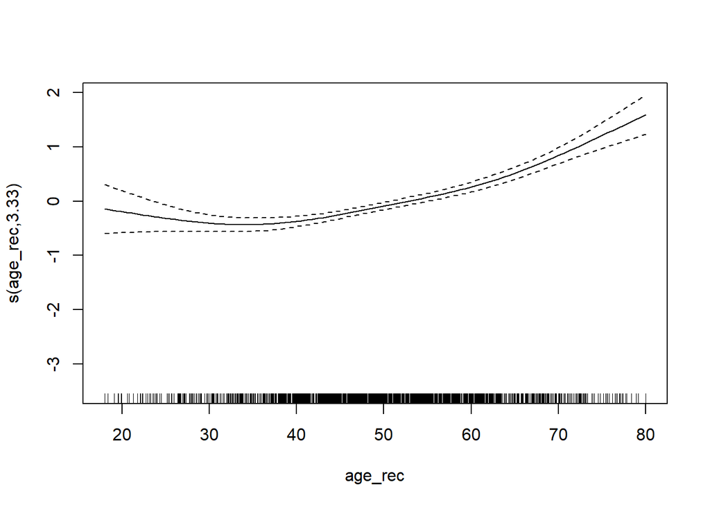

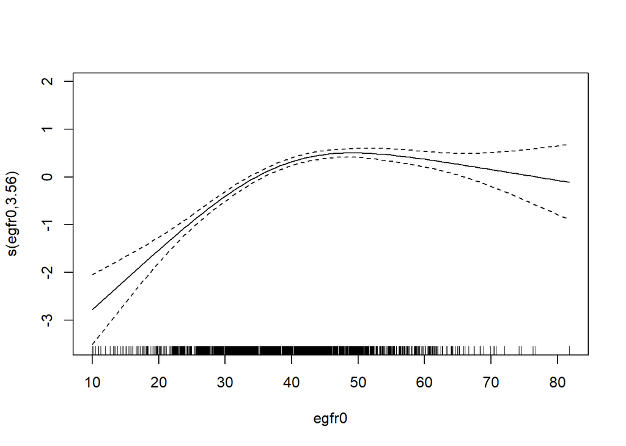

```r
plot(gam_cox)
```

we also could get the prediction plot using `ggplot2` as follows:

✅ **eGFR at baseline**

These predictions are for a **male recipient** receiving a kidney from a **deceased donor**, at **median age**.

**Show R code**

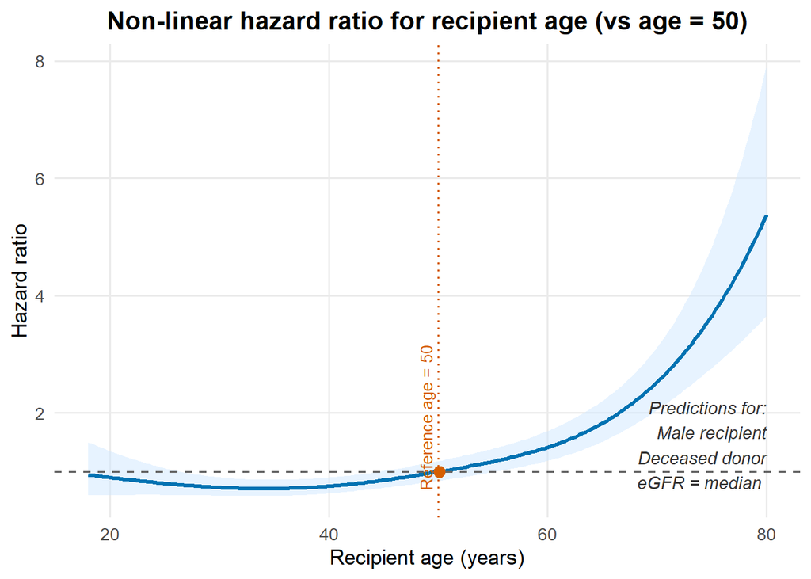

```r
library(ggplot2)



df<-nonlinear_data

#age
age_seq <- seq(min(df$age_rec), max(df$age_rec), length.out = 200)
new_age <- data.frame(
  age_rec       = age_seq,
  egfr0         = median(df$egfr0),
  donor_type    = "Deceased",
  recipient_sex = "Male"
)

pred <- predict(gam_cox, newdata = new_age, type = "link", se.fit = TRUE)

# Reference at age 50
ref_index <- which.min(abs(age_seq - 50))
ref       <- pred$fit[ref_index]
logHR     <- pred$fit - ref

plot_age <- data.frame(
  age_rec = age_seq,
  HR      = exp(logHR),
  lo      = exp(logHR - 1.96 * pred$se.fit),
  hi      = exp(logHR + 1.96 * pred$se.fit)
)

ref_point <- plot_age[ref_index, ]



ggplot(plot_age, aes(x = age_rec, y = HR)) +
  # CI ribbon
  geom_ribbon(aes(ymin = lo, ymax = hi),
              fill = "#cfe8ff", alpha = 0.5) +
  # HR curve
  geom_line(colour = "#0072B2", linewidth = 1.1) +
  # Horizontal HR=1
  geom_hline(yintercept = 1, linetype = "dashed", colour = "grey40") +
  # Vertical reference at age 50
  geom_vline(xintercept = 50, linetype = "dotted", colour = "#D55E00") +
  # Highlight reference point
  geom_point(data = ref_point,
             aes(x = age_rec, y = HR),
             colour = "#D55E00", size = 3) +
  # Annotation for age 50
  annotate("text",
           x = 50, y = max(plot_age$HR, na.rm = TRUE),
           label = "Reference age = 50",
           colour = "#D55E00", angle = 90,
           vjust = -0.5, hjust = 1.9, size = 3.5) +
  # New annotation for scenario (male recipient + deceased donor)
  annotate("text",
           x = max(plot_age$age_rec),
           y = min(plot_age$HR),
           label = "Predictions for:\nMale recipient\nDeceased donor\neGFR = median ",
           hjust = 1, vjust = 0,
           colour = "grey20", size = 3.8,
           fontface = "italic") +
  labs(
    title = "Non-linear hazard ratio for recipient age (vs age = 50)",
    x     = "Recipient age (years)",
    y     = "Hazard ratio"
  ) +
  theme_minimal(base_size = 13) +
  theme(
    plot.title   = element_text(face = "bold", hjust = 0.5),
    panel.grid.minor = element_blank()
  )
```

✅ **Age**

The effect of recipient age on graft failure is strongly non-linear. Compared with a 50-year-old recipient (HR = 1):

- **Younger adults (<40)** have a slightly lower hazard, but the protective effect is modest.
- **Ages 50–60** show a gradual increase in hazard.
- **Older ages (>60)** display a rapid, accelerating increase in hazard, with much higher risk by age 75–80.

These predictions are for a **male recipient** receiving a kidney from a **deceased donor**, at **median of eGFR**.

**Show R code**

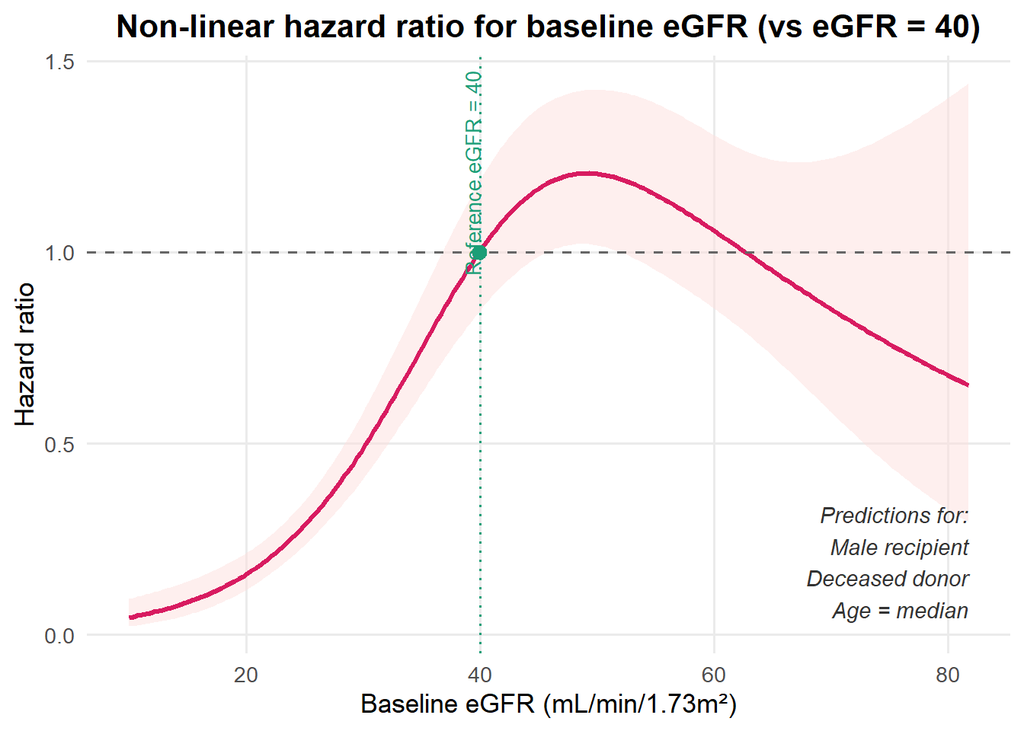

```r
#egfr
egfr_seq <- seq(min(df$egfr0), max(df$egfr0), length.out = 200)

new_egfr <- data.frame(
  age_rec       = median(df$age_rec),
  egfr0         = egfr_seq,
  donor_type    = "Deceased",
  recipient_sex = "Male"
)

pred2 <- predict(gam_cox, newdata = new_egfr, type = "link", se.fit = TRUE)

# Reference at eGFR = 40
ref_index2 <- which.min(abs(egfr_seq - 40))
ref2       <- pred2$fit[ref_index2]
logHR2     <- pred2$fit - ref2

plot_egfr <- data.frame(
  egfr0 = egfr_seq,
  HR    = exp(logHR2),
  lo    = exp(logHR2 - 1.96 * pred2$se.fit),
  hi    = exp(logHR2 + 1.96 * pred2$se.fit)
)

ref_point2 <- plot_egfr[ref_index2, ]

library(ggplot2)

ggplot(plot_egfr, aes(x = egfr0, y = HR)) +
  # CI ribbon
  geom_ribbon(aes(ymin = lo, ymax = hi),
              fill = "#fde0dd", alpha = 0.5) +
  # HR curve
  geom_line(colour = "#D81B60", linewidth = 1.1) +
  # Horizontal HR=1 line
  geom_hline(yintercept = 1, linetype = "dashed", colour = "grey40") +
  # Vertical line at eGFR=40
  geom_vline(xintercept = 40, linetype = "dotted", colour = "#1B9E77") +
  # Highlight reference point
  geom_point(data = ref_point2,
             aes(x = egfr0, y = HR),
             colour = "#1B9E77", size = 3) +
  # Annotation for reference
  annotate("text",
           x = 40, y = max(plot_egfr$HR, na.rm = TRUE),
           label = "Reference eGFR = 40",
           colour = "#1B9E77", angle = 90,
           vjust = 0.001, hjust = 0.5, size = 3.5) +
  # Scenario annotation
  annotate("text",
           x = max(plot_egfr$egfr0),
           y = min(plot_egfr$HR),
           label = "Predictions for:\nMale recipient\nDeceased donor\nAge = median",
           hjust = 1, vjust = 0,
           colour = "grey20", size = 3.8,
           fontface = "italic") +
  labs(
    title = "Non-linear hazard ratio for baseline eGFR (vs eGFR = 40)",
    x     = "Baseline eGFR (mL/min/1.73m²)",
    y     = "Hazard ratio"
  ) +
  theme_minimal(base_size = 13) +
  theme(
    plot.title   = element_text(face = "bold", hjust = 0.5),
    panel.grid.minor = element_blank()
  )
```

**TipInterpretation of covariate effects (linear components)**

✅ **Donor type (living vs deceased)**

HR = 0.63, *P* < 0.001, Statistically significant.  
Recipients of a **living donor kidney** have approximately a **37% lower hazard of graft failure** compared with recipients of deceased-donor kidneys, indicating a **strong protective effect**.

✅ **Recipient sex (female vs male)**

HR = 1.07, *P* = 0.299, Not statistically significant.  
Female recipients show a slightly higher estimated hazard compared with males, but this difference is **not statistically significant**, and there is **no strong evidence of a sex effect** on graft failure risk.